# Problema3-checkPoint4

Arthur Sena

20-05-2015

```r
  library(ggplot2, quietly = T, warn.conflicts = F)
  library(dplyr, quietly = T, warn.conflicts = F)
```

# Descrição dos Dados

Os nossos dados são referentes aos gols do campeonato brasileiro de 2013. Onde, no total, nós temos um conjunto com 973 observações cada uma com 7 colunas/variáveis. Uma pequena amostra dos dados pode ser visualizada logo abaixo:

```r
     gols<-read.csv("camp brasileiro 2013 - dados processados copy.csv")
     head(gols)
```

```
##   id_jogo        time_a        time_b tempo_gol      time_gol
## 1       1 Vasco da Gama    Portuguesa        47 Vasco da Gama
## 2       2       Vitória Internacional         2       Vitória
## 3       2       Vitória Internacional        11       Vitória
## 4       2       Vitória Internacional        29 Internacional
## 5       2       Vitória Internacional        63 Internacional
## 6       3   Corinthians      Botafogo        24      Botafogo
##   placar_time_a placar_time_b
## 1             1             0
## 2             1             0
## 3             2             0
## 4             2             1
## 5             2             2
## 6             0             1
```

Os dados acima apresentam uma columa de “tempo_gol”, na qual representa o minuto em que um determinado gol ocorreu naquele jogo. Para efeito de melhor visualização e entendimento dos dados, nós podemos criar um histograma com a frequência de gols em cada tempo do jogo.

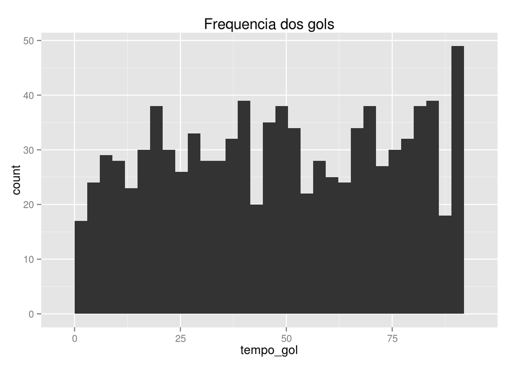

```r
        gols <- filter(gols,tempo_gol != "None")
        gols$tempo_gol <- as.numeric(gols$tempo_gol)

        tempo1 <- filter(gols,tempo_gol <= 45)
        tempo2 <- filter(gols,tempo_gol > 45)
        tempo2$tempo_gol <- tempo2$tempo_gol - 45

        qplot(data = gols, tempo_gol, geom = "histogram")+ggtitle("Frequencia dos gols")
```

# Análise dos Dados

Com esses dados em mãos podemos tentar responder algumas perguntas interessantes, como por exemplo:

**1)Existe uma diferença significativa entre a média do tempo de gols entre o 1º e o 2º turno do campeonato ?**

O primeiro passo para responder tal pergunta e agrupar os gols em dois grupos: 1º turno e 2º turno. Feito isso, podemos usar um simples teste de hipóteses, no qual minhas hipóteses poderiam ser:

__H0:__Não existe diferença significativa.  
__H1:__Existe uma diferença significativa.

Após definida as hipóteses, podemos então calcular o nosso p-value.

```r
     gols<-read.csv("camp brasileiro 2013 - dados processados copy.csv")
     gols <- filter(gols,tempo_gol != "None")
     gols$tempo_gol <- as.numeric(gols$tempo_gol)

     turno_1 <- filter(gols, id_jogo <= 190)
     turno_2 <- filter(gols, id_jogo > 190)
     t.test(turno_1$tempo_gol,turno_2$tempo_gol)
```

```
##
##  Welch Two Sample t-test
##
## data:  turno_1$tempo_gol and turno_2$tempo_gol
## t = 1.0184, df = 933.328, p-value = 0.3088
## alternative hypothesis: true difference in means is not equal to 0
## 95 percent confidence interval:
##  -1.639447  5.176246
## sample estimates:
## mean of x mean of y
##  48.93763  47.16923
```

Observando o resultado do teste notamos que o p-value se encontra acima de 5%, ou seja, não podemos refutar a nossa hipótese nula. A fim de obter uma análise mais completa, podemos calcular o Intervalo de Confiança da média de cada turno.

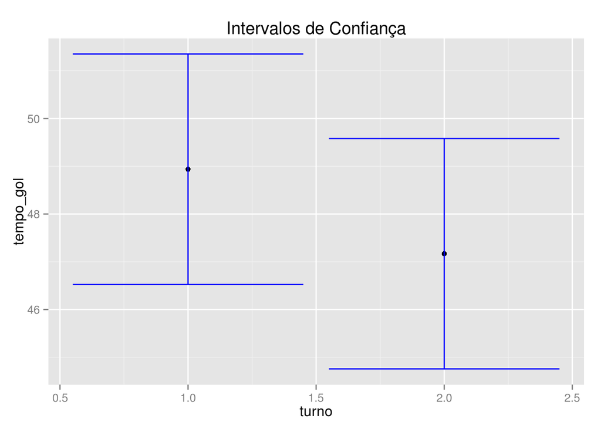

```r
     gols<-read.csv("camp brasileiro 2013 - dados processados copy.csv")
     gols <- filter(gols,tempo_gol != "None")
     gols$tempo_gol <- as.numeric(gols$tempo_gol)

    gols$turno <- 0

      for (i in seq(1,nrow(gols))){
           if (gols[i,1] <= 190){
                gols[i,8] <- 1
             }
           else{
            gols[i,8] <- 2
           }
      }

       ggplot(gols, aes(x = turno, y = tempo_gol)) +
          stat_summary(fun.y = mean, geom = "point") +
          stat_summary(fun.data = mean_cl_normal, geom = "errorbar", colour = "blue",) + ggtitle("Intervalos de Confiança")
```

Observando o gráfico acima notamos que os intervalos das médias, praticamente, sobrepõem um ao outro, ou seja, não existe diferença significativa entre eles com 95% de confiança.

**2) Existe uma diferença significativa entre a média do tempo de gol do campeão do campeonato em relação aos demais times ?**

A fim de responder essa questão, vamos precisar selecionar os gols marcados pelo campeão da nossa amostra e comparar com o tempo dos gols dos demais times. Antes disso, vamos definir nossas hipóteses:

__H0:__Não existe diferença significativa entre a média do tempo de gols do campeão com os demais times.  
__H1:__Existe uma diferença significativa entre a média do tempo de gols do campeão com os demais.

```r
    gols<-read.csv("camp brasileiro 2013 - dados processados copy.csv")
    gols <- filter(gols,tempo_gol != "None")
    gols$tempo_gol <- as.numeric(gols$tempo_gol)

    gols_campeao <- filter(gols, time_gol == "Cruzeiro")
    demais_times <- filter(gols, time_gol != "Cruzeiro")

   t.test(gols_campeao$tempo_gol,demais_times$tempo_gol)
```

```
##
##  Welch Two Sample t-test
##
## data:  gols_campeao$tempo_gol and demais_times$tempo_gol
## t = 0.5063, df = 90.865, p-value = 0.6139
## alternative hypothesis: true difference in means is not equal to 0
## 95 percent confidence interval:
##  -4.591793  7.733198
## sample estimates:
## mean of x mean of y
##  49.51948  47.94878
```

Novamente notamos que o p-value apresenta um valor maior que 5%, ou seja, não podemos refutar a nossa hipótese nula. Assim sendo, visualizando o gráfico de intervalo de confiança devemos observar os intervalos sobrepondo um ao outro.

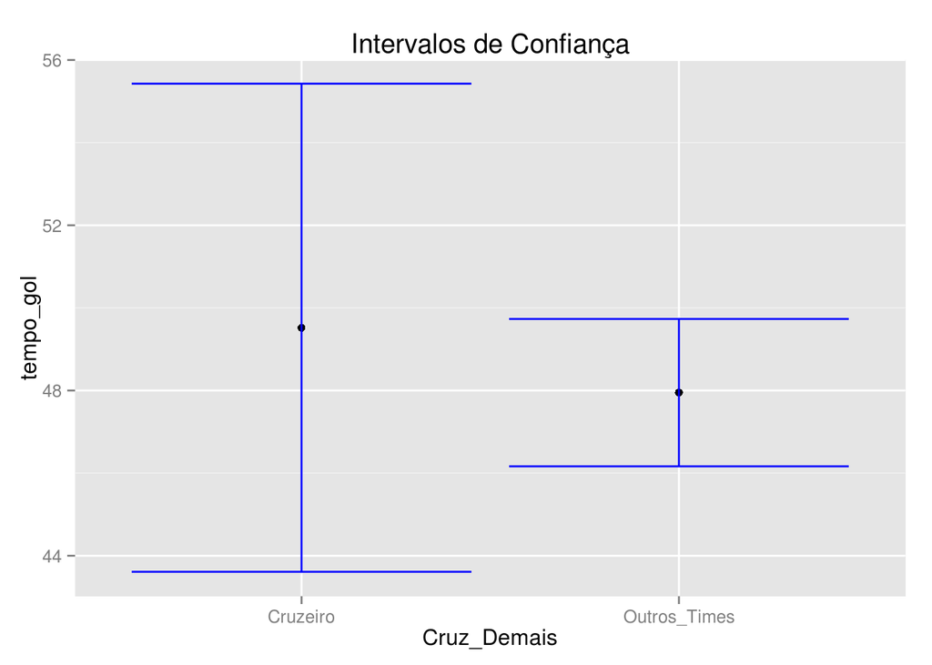

```r
  gols<-read.csv("camp brasileiro 2013 - dados processados copy.csv")
    gols <- filter(gols,tempo_gol != "None")
    gols$tempo_gol <- as.numeric(gols$tempo_gol)


    gols$Cruz_Demais <- "X"

    for (i in seq(1,nrow(gols))){
           if (gols[i,5] == "Cruzeiro"){
                gols[i,8] <- "Cruzeiro"
             }
           else{
            gols[i,8] <- "Outros_Times"
           }
      }

   ggplot(gols, aes(x = Cruz_Demais, y = tempo_gol)) +
          stat_summary(fun.y = mean, geom = "point") +
          stat_summary(fun.data = mean_cl_normal, geom = "errorbar", colour = "blue",) + ggtitle("Intervalos de Confiança")
```

Como esperado os intervalos sobrepõe um ao outro.

**3)Existe uma diferença significativa entre a média do tempo de gols dos times que foram rebaixados em relação aos demais times?**

Mais uma vez, vamos agrupar nossos dados em dois grupos: O grupo dos times que permaneceram na série A e os times que foram rebaixados para série B. Antes disso, vamos calcular nossas hipóteses:

__H0:__Não existe diferença significativa entre a média do tempo de gols dos times rebaixados com os demais times.  
__H1:__Existe uma diferença significativa entre a média do tempo de gols dos times rebaixados com os demais times.

```r
    gols<-read.csv("camp brasileiro 2013 - dados processados copy.csv")
    gols <- filter(gols,tempo_gol != "None")
    gols$tempo_gol <- as.numeric(gols$tempo_gol)

    rebaixados <- filter(gols, time_gol == "Portuguesa" | time_gol == "Vasco da Gama" | time_gol == "Ponte Preta" |time_gol ==                      "Náutico" )

    demais_times<- filter(gols, time_gol != "Portuguesa" & time_gol != "Vasco da Gama" & time_gol != "Ponte Preta" &time_gol !=                      "Náutico" )

   t.test(rebaixados$tempo_gol,demais_times$tempo_gol)
```

```
##
##  Welch Two Sample t-test
##
## data:  rebaixados$tempo_gol and demais_times$tempo_gol
## t = 1.1303, df = 223.275, p-value = 0.2596
## alternative hypothesis: true difference in means is not equal to 0
## 95 percent confidence interval:
##  -1.980567  7.308218
## sample estimates:
## mean of x mean of y
##  50.28931  47.62548
```

E, novamente, o p-value se encontra sendo maior que 5%, ou seja, não podemos descartar a hipótese nula.